# Minfi vs sesame comparison

## Setup

Loading packages

```r
library(minfi)
library(sesame)
library(tidyverse)
```

Below is a custom function to go from idat files to beta values using **minfi**.

```r
idat_to_beta_values_noob <- function(...) {
  RGset <- read.metharray.exp(...)
  RGset@annotation = c(array = "IlluminaHumanMethylationEPIC", annotation = "ilm10b4.hg19")

  MSet.noob <- preprocessNoob(RGset, offset = 15, dyeCorr = TRUE, verbose = TRUE)

  ratioSet.noob <- ratioConvert(MSet.noob, what =  "both", keepCN = TRUE)
  beta.noob <- getBeta(ratioSet.noob)
  beta.noob
}
```

```r
idat_folder <- "~/Data/methylation/idat"
data_directory <- "~/Data/methylation/directory.csv"
```

## Minfi

Example of extraction of beta values for 1 sample using **minfi**.

```r
minfi_data <- idat_to_beta_values_noob(
  base = idat_folder,
  targets = data.frame(Basename = "200514030126_R06C01",
                       stringsAsFactors = FALSE)
)
```

Plotting the distribution gives us a bimodal distribution.

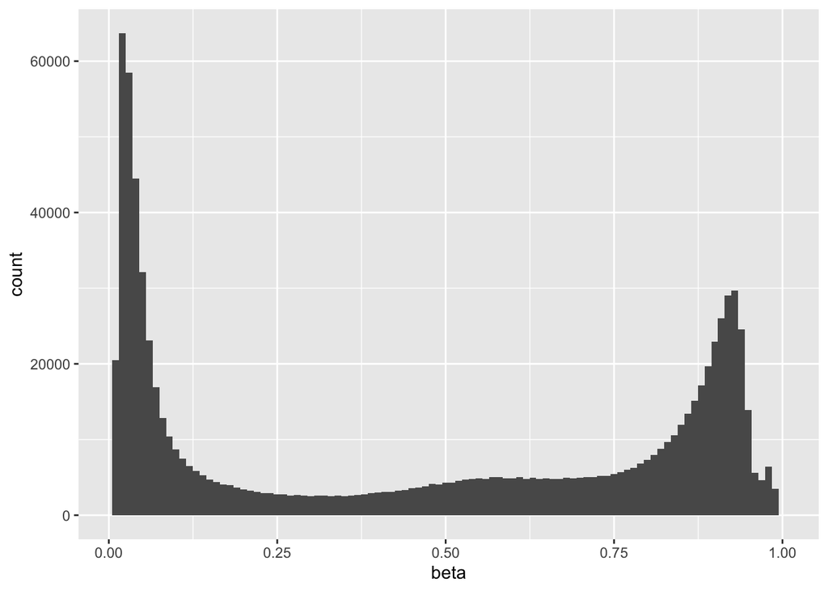

```r
tibble(beta = minfi_data[, 1]) %>%
  ggplot(aes(beta)) +
  geom_histogram(bins = 100)
```

## Sessme

Example of extraction of beta values for 1 sample using **sesame**.

```r
sesame_data <- openSesame(file.path(idat_folder, "200514030126_R06C01"))
```

Plotting the distribution gives us a bimodal distribution. `NA` were dropped before plotting.

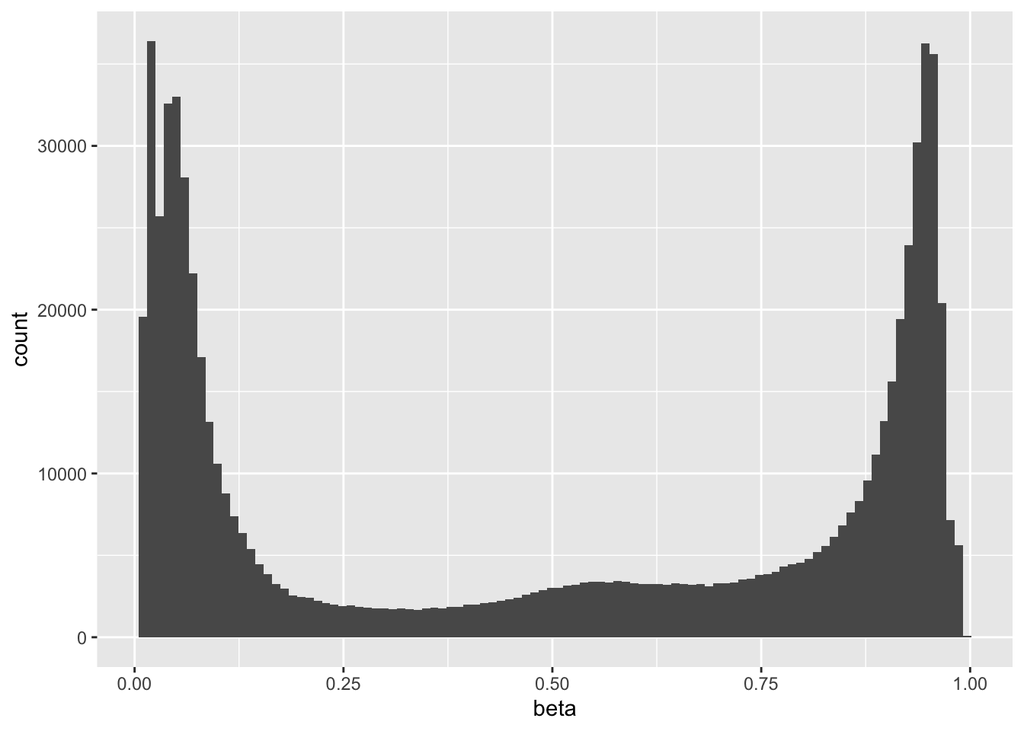

```r
tibble(beta = sesame_data) %>%
  drop_na() %>%
  ggplot(aes(beta)) +
  geom_histogram(bins = 100)
```

## Visual comparison

The following function takes a vector of basenames and extracts the beta values using **minfi** and **sesame**. Sesame it set to perform pOOBAH masking which will show up as missing values.

```r
com_data <- function(x) {
  minfi_beta <- idat_to_beta_values_noob(base = idat_folder,
                         targets = data.frame(Basename = x,
                                              stringsAsFactors = FALSE))

  sesame_beta <- openSesame(file.path(idat_folder, x))

  data.frame(package = rep(c("minfi", "sesame"), c(length(minfi_beta), length(sesame_beta))),
             beta = c(minfi_beta[, 1], sesame_beta),
             site = c(rownames(minfi_beta), names(sesame_beta)),
             stringsAsFactors = FALSE)
}
```

A single sample is used and frequency polygons is created of the densities.

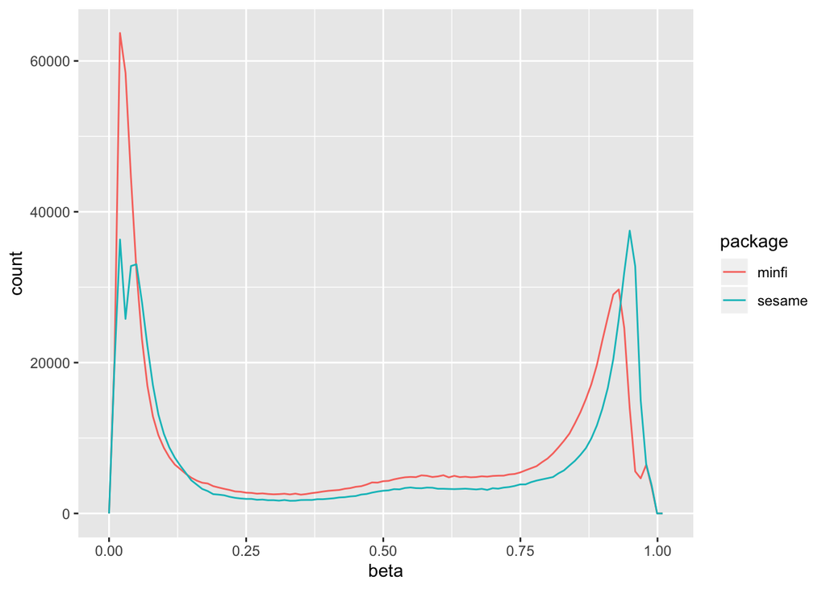

```r
sample_1 <- com_data(x = "200514030126_R06C01")

sample_1 %>%
  ggplot(aes(beta, color = package)) +
  geom_freqpoly(bins = 100)
```

## Investigate by plate and well id

The following function takes two arguments, plate and well and plots the density chart.

```r
com_plot <- function(plate, well) {
  read_csv(data_directory,
         col_types = cols_only(
           plate = col_double(),
           well_position = col_character(),
           basename = col_character()
           )
         ) %>%
  filter(plate == .env$plate, well_position == well) %>%
  pull(basename) %>%
  com_data() %>%
  ggplot(aes(beta, color = package)) +
  geom_freqpoly(bins = 100) +
  labs(title = paste0(plate, "-", well))
}
```

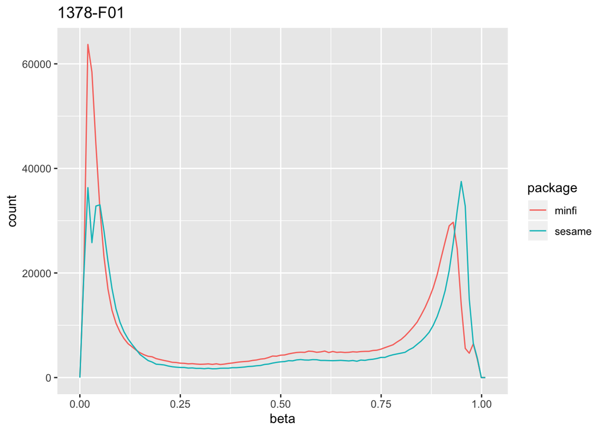

```r
com_plot(1378, "F01")
```

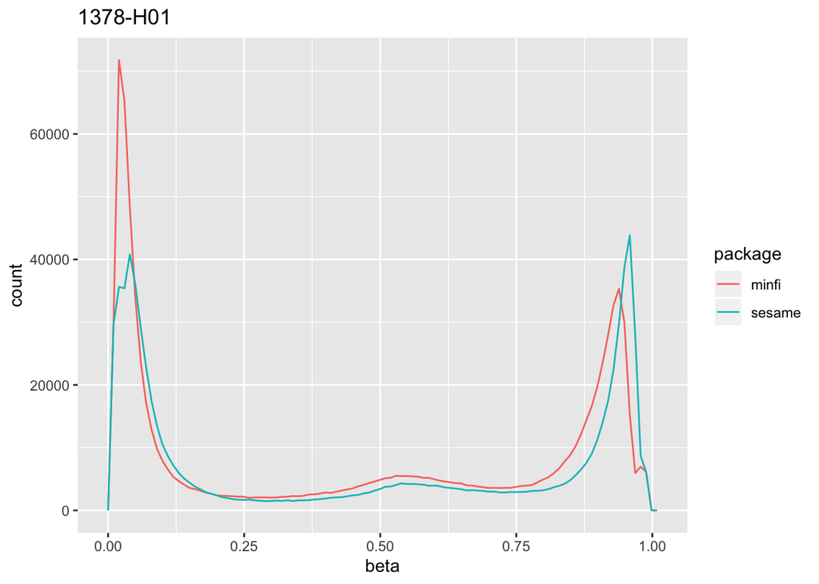

```r
com_plot(1378, "H01")
```

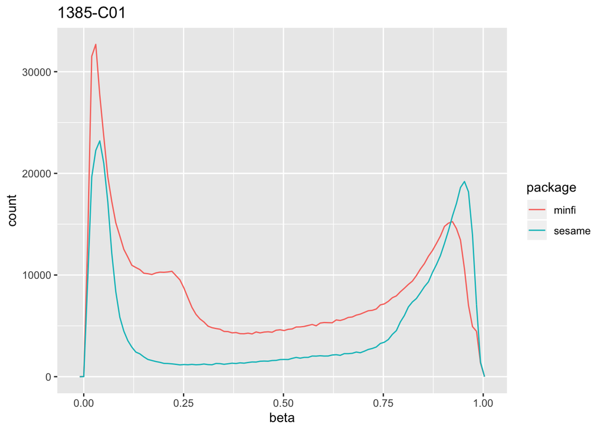

```r
com_plot(1385, "C01")
```

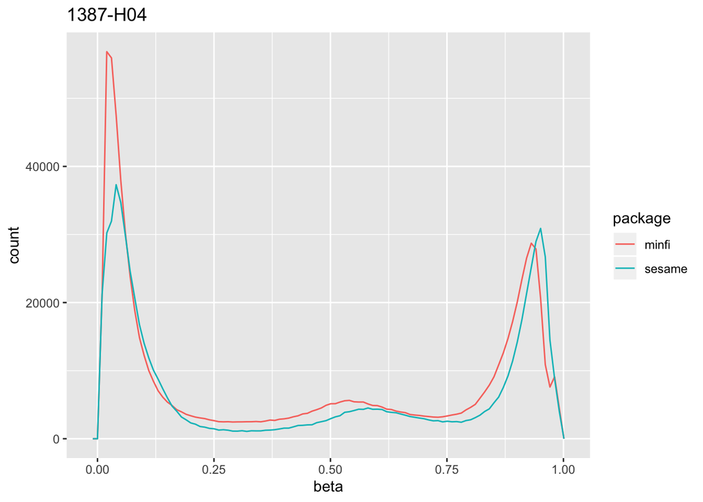

```r
com_plot(1387, "H04")
```

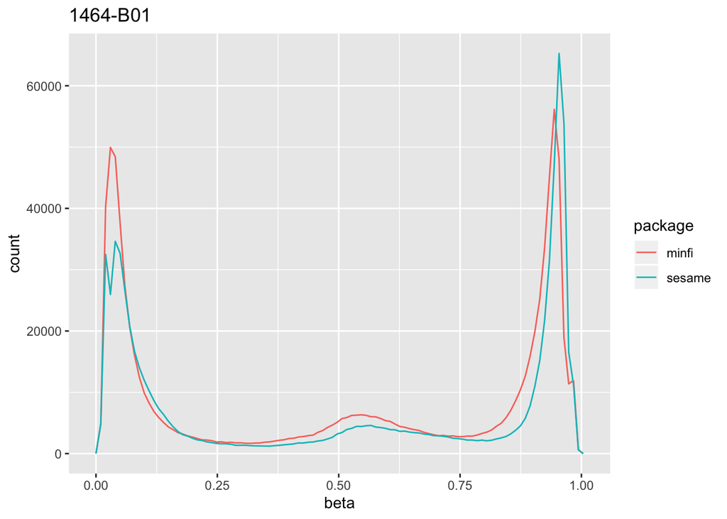

```r
com_plot(1464, "B01")
```

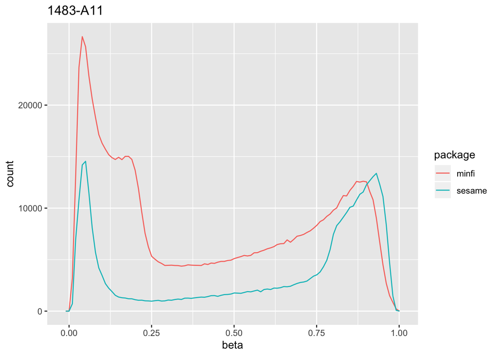

```r
com_plot(1483, "A11")
```

## Comparing amount of masking by region

Following function take the arguments plate and well and returns the result of beta estimation. Works the same as `com_data` but input is plate and well instead of basename.

```r
com_region <- function(plate, well) {
  base_names <- read_csv(data_directory,
         col_types = cols_only(
           plate = col_double(),
           well_position = col_character(),
           basename = col_character()
           )
         ) %>%
  filter(plate == .env$plate, well_position == well) %>%
  pull(basename)

  betas <- openSesame(file.path(idat_folder, base_names))

  tibble(site = names(betas),
         beta = betas,
         sample = paste(plate, well))
}
```

Following charts showchange the total count within each region compared to the count of masked cpgs.

```r
island_ref <- tibble(
island = Islands.UCSC@listData$Relation_to_Island,
rownames = Islands.UCSC@rownames
)
```

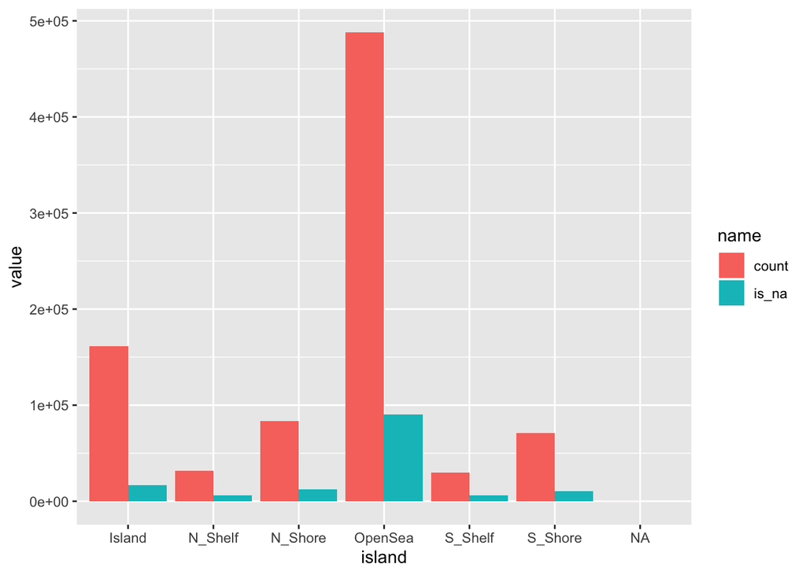

```r
ddd <- com_region(1378, "F01")

ddd %>%
  left_join(island_ref, by = c("site" = "rownames")) %>%
  group_by(island) %>%
  summarise(count = n(),
            is_na = sum(is.na(beta))) %>%
  pivot_longer(count:is_na) %>%
  ggplot(aes(island, value, fill = name)) +
  geom_col(position = "dodge")
```

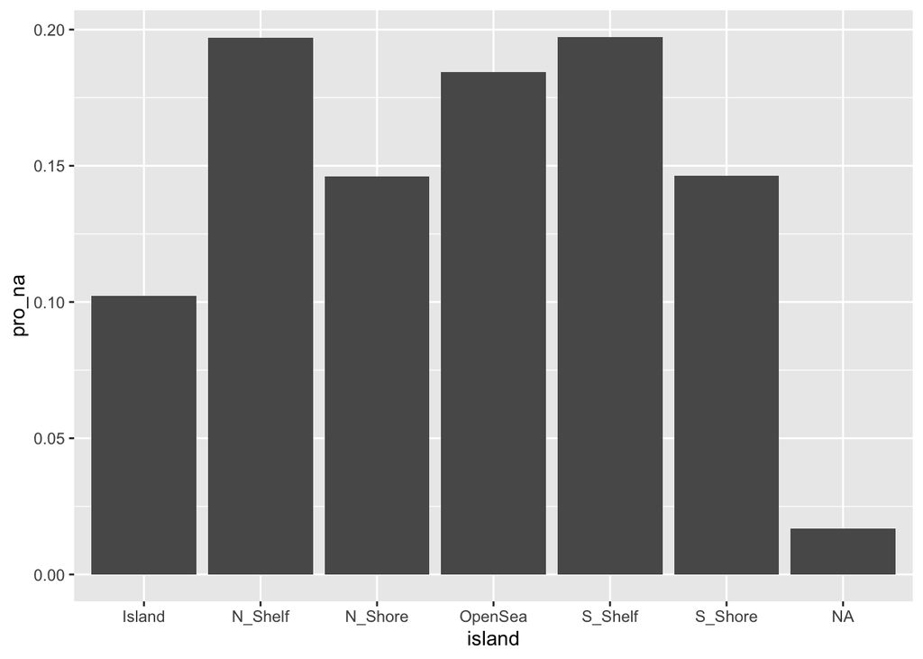

```r
ddd %>%
  left_join(island_ref, by = c("site" = "rownames")) %>%
  group_by(island) %>%
  summarise(pro_na = sum(is.na(beta)) / n()) %>%
  ggplot(aes(island, pro_na)) +
  geom_col()
```

## All the sample

Here we calculate the beta values for all the sample labeled as “tumor gland”.

```r
all_data <- read_csv(data_directory) %>%
  filter(description == "tumor gland") %>%
  select(plate, well_position) %>%
  pmap_dfr(~ com_region(.x, .y))
```

### Islands regions

Each sample is represented by a point in each column.

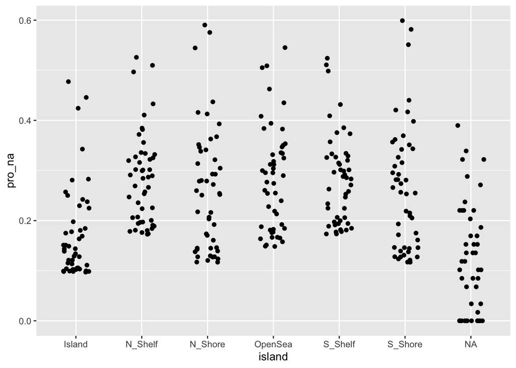

```r
all_data %>%
   left_join(island_ref, by = c("site" = "rownames")) %>%
  group_by(sample, island) %>%
  summarise(pro_na = sum(is.na(beta)) / n()) %>%
  ggplot(aes(island, pro_na)) +
  geom_jitter(height = 0, width = 0.2)
```

A connected line chart shows that the variability of the procentage of masked points don’t overlap.

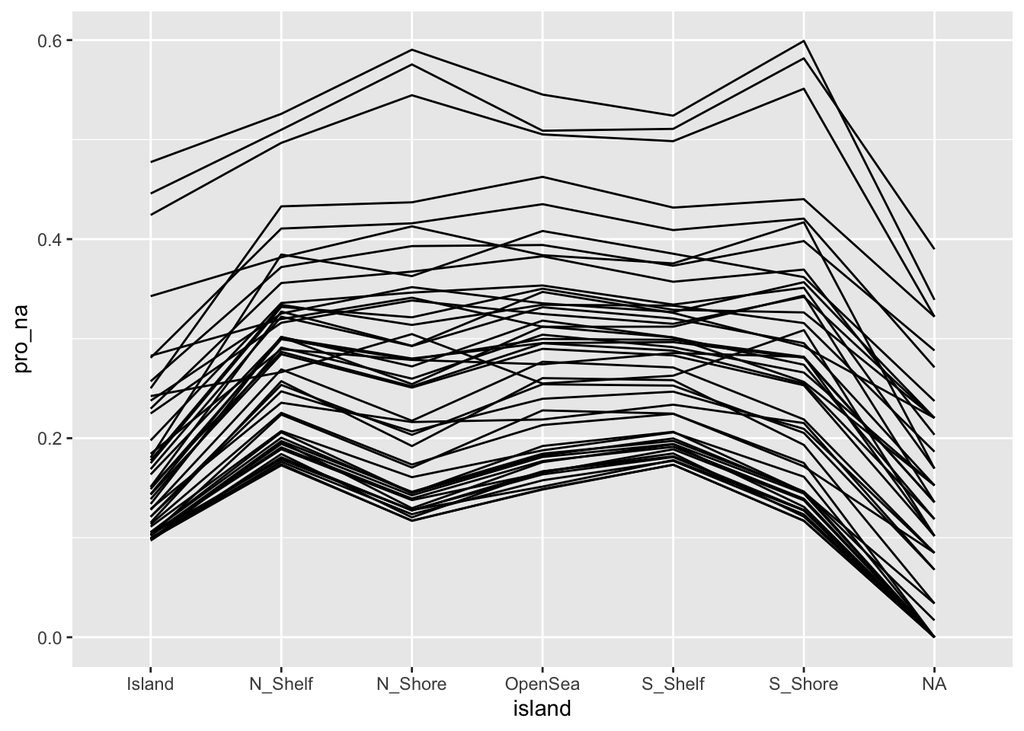

```r
all_data %>%
  mutate(island = Islands.UCSC@listData$Relation_to_Island[match(site, Islands.UCSC@rownames)]) %>%
  group_by(sample, island) %>%
  summarise(pro_na = sum(is.na(beta)) / n()) %>%
  ggplot(aes(island, pro_na)) +
  geom_line(aes(group = sample))
```

Below is a side by side comparrison between the number of sites within each region (on the left) and the procentages of cpg site for which at least of the the 48 sample have been masked.

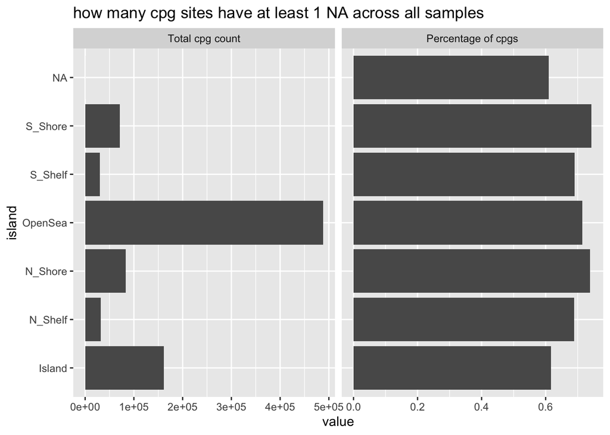

```r
fff <- all_data %>%
  group_by(site) %>%
  summarise(union_na = any(is.na(beta))) %>%
  mutate(island = Islands.UCSC@listData$Relation_to_Island[match(site, Islands.UCSC@rownames)])

fff %>%
  group_by(island) %>%
  summarise(count = n(),
            procent = mean(union_na)) %>%
  pivot_longer(count:procent) %>%
  mutate(name = factor(name, c("count", "procent"),
                       c("Total cpg count", "Percentage of cpgs"))) %>%
  ggplot(aes(island, value)) +
  geom_col() +
  coord_flip() +
  facet_wrap(~name, scales = "free_x") +
  labs(title = "how many cpg sites have at least 1 NA across all samples")
```

## Promotor regions

Below is same plots as in islands regions but with promotor regions instead.

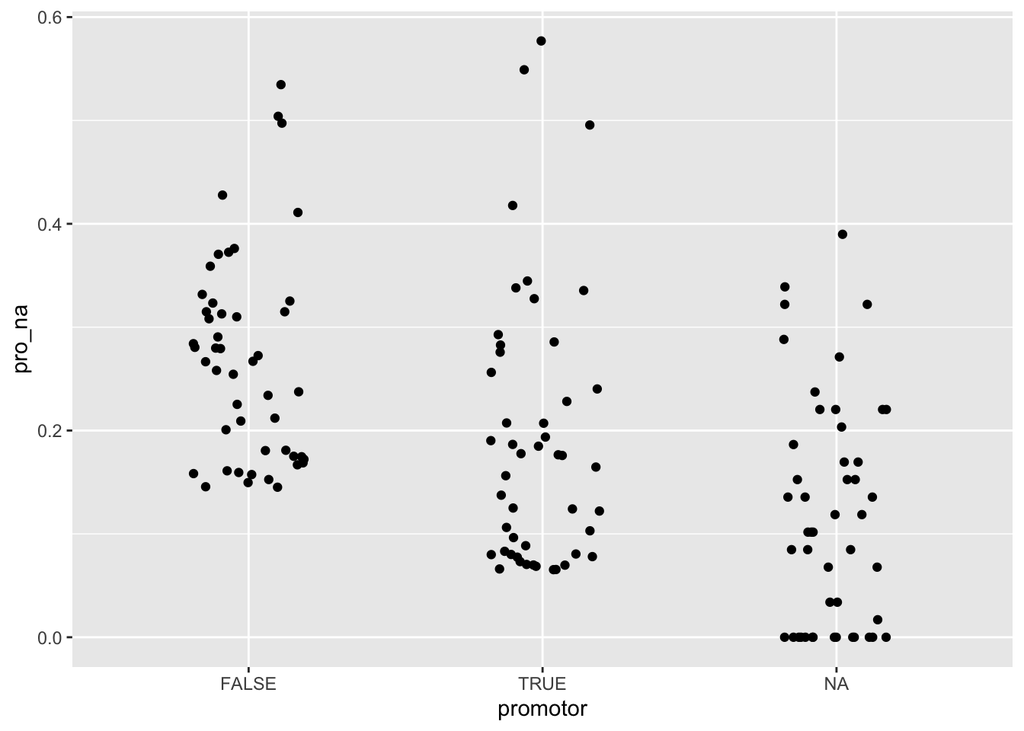

```r
all_data %>%
  mutate(island = Other@listData$Regulatory_Feature_Group[match(site, Other@rownames)]) %>%
  mutate(promotor = island == "Promoter_Associated") %>%
  group_by(sample, promotor) %>%
  summarise(pro_na = sum(is.na(beta)) / n()) %>%
  ggplot(aes(promotor, pro_na)) +
  geom_jitter(height = 0, width = 0.2)
```

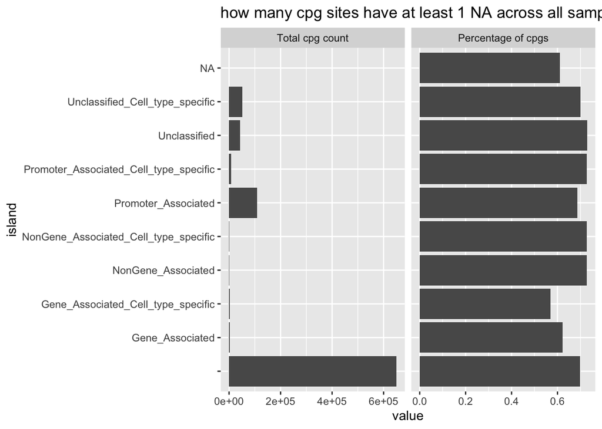

```r
fffpro <- all_data %>%
  group_by(site) %>%
  summarise(union_na = any(is.na(beta))) %>%
  mutate(island = Other@listData$Regulatory_Feature_Group[match(site, Other@rownames)]) %>%
  mutate(promotor = island == "Promoter_Associated")

fffpro %>%
  group_by(island) %>%
  summarise(count = n(),
            procent = mean(union_na)) %>%
  pivot_longer(count:procent) %>%
  mutate(name = factor(name, c("count", "procent"),
                       c("Total cpg count", "Percentage of cpgs"))) %>%
  ggplot(aes(island, value)) +
  geom_col() +
  coord_flip() +
  facet_wrap(~name, scales = "free_x") +
  labs(title = "how many cpg sites have at least 1 NA across all samples")
```